# **Deep Learning Project: Street View Housing Number Digit Recognition**

# **Marks: 60**

## **Context**

One of the most interesting tasks in deep learning is to recognize objects in natural scenes. The ability to process visual information using machine learning algorithms can be very useful as demonstrated in various applications.

The SVHN dataset contains over 600,000 labeled digits cropped from street-level photos. It is one of the most popular image recognition datasets. It has been used in neural networks created by Google to improve the map quality by automatically transcribing the address numbers from a patch of pixels. The transcribed number with a known street address helps pinpoint the location of the building it represents.

## **Objective**

Our objective is to predict the number depicted inside the image by using Artificial or Fully Connected Feed Forward Neural Networks and Convolutional Neural Networks. We will go through various models of each and finally select the one that is giving us the best performance.

## **Dataset**

Here, we will use a subset of the original data to save some computation time. The dataset is provided as a .h5 file. The basic preprocessing steps have been applied on the dataset.

## **Mount the drive**

Let us start by mounting the Google drive. You can run the below cell to mount the Google drive.

```python
# let colab access my google drive
from google.colab import drive
drive.mount('/content/drive')
```

## **Importing the necessary libraries**

```python
!pip install tensorflow
```

[output not shown]

```python
# let's load our libraries

import warnings
warnings.filterwarnings('ignore')

import zipfile
import os
import h5py

from tqdm import tqdm

import pandas as pd
import numpy as np
import matplotlib.pyplot as plt
import seaborn as sns
import random
import psutil

from sklearn.model_selection import train_test_split
from sklearn.preprocessing import StandardScaler, LabelEncoder
from sklearn.metrics import classification_report, confusion_matrix, ConfusionMatrixDisplay, accuracy_score, precision_score, recall_score, f1_score,roc_auc_score
from sklearn.metrics import roc_curve, auc

import tensorflow as tf
from tensorflow.keras.models import Sequential, load_model
from tensorflow.keras.optimizers import Adam
from tensorflow.keras.layers import Input, Dense, Dropout, Conv2D, MaxPooling2D, Flatten, BatchNormalization, LeakyReLU
from tensorflow.keras.callbacks import EarlyStopping, ModelCheckpoint, ReduceLROnPlateau
from tensorflow.keras.utils import to_categorical
import tensorflow.keras.backend as K

from tensorflow.keras.preprocessing.image import ImageDataGenerator
from tensorflow.keras.applications import VGG16
from tensorflow.keras.metrics import CategoricalAccuracy
```

**Let us check the version of tensorflow.**

```python
print("TensorFlow version:", tf.__version__)
```

```
TensorFlow version: 2.19.0
```

```python
# I want to check my memory
mem = psutil.virtual_memory()
print(f"Used: {mem.used / 1e9:.2f} GB, Available: {mem.available / 1e9:.2f} GB")
```

```
Used: 2.58 GB, Available: 354.23 GB
```

## **Load the dataset**

- Let us now load the dataset that is available as a .h5 file.
- Split the data into the train and the test dataset.

```python
file_path = '/content/drive/MyDrive/MIT - Applied Data Science Program: Leveraging AI for Effective Decision-Making/Elective Project/SVHN_single_grey1.h5'
```

```python
# let's see what datasets we have in our .h5 file (HDF5)
with h5py.File(file_path, 'r') as hf:
    print("Keys in the file:")
    for key in hf.keys():
        print(key)
```

```
Keys in the file:
X_test
X_train
X_val
y_test
y_train
y_val
```

```python
# let's extract the data used for training, validation, and testing and print the shape of the datasets
with h5py.File(file_path, 'r') as hf:
    X_train = np.array(hf['X_train'])
    y_train = np.array(hf['y_train'])
    X_val = np.array(hf['X_val'])
    y_val = np.array(hf['y_val'])
    X_test = np.array(hf['X_test'])
    y_test = np.array(hf['y_test'])

print("X_train shape:", X_train.shape)
print("y_train shape:", y_train.shape)
print("X_val shape:", X_val.shape)
print("y_val shape:", y_val.shape)
print("X_test shape:", X_test.shape)
print("y_test shape:", y_test.shape)
```

```
X_train shape: (42000, 32, 32)
y_train shape: (42000,)
X_val shape: (60000, 32, 32)
y_val shape: (60000,)
X_test shape: (18000, 32, 32)
y_test shape: (18000,)
```

Check the number of images in the training and the testing dataset.

```python
print("Number of training images:", X_train.shape[0])
print("Number of validation images:", X_val.shape[0])
print("Total training-related images (train + val):", X_train.shape[0] + X_val.shape[0])
print("Number of test images:", X_test.shape[0])
```

```
Number of training images: 42000
Number of validation images: 60000
Total training-related images (train + val): 102000
Number of test images: 18000
```

**Observation:**

The dataset has a lot of images: 42,000 for training, 60,000 for validation, and 18,000 for testing. It is a bit unusual that the validation set is bigger than the training set, but this might help us check how well the model works. Overall, having so many images in each set is good for training and testing our neural networks properly.

## **Visualizing images**

- Use X_train to visualize the first 10 images.
- Use Y_train to print the first 10 labels.

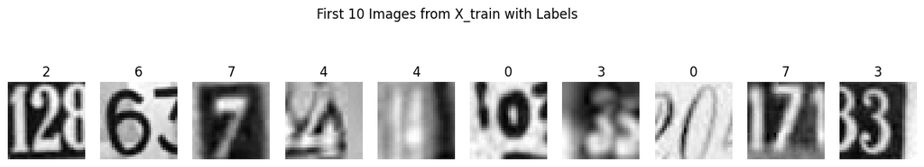

```python
#let's see what do our images look like
plt.figure(figsize=(15, 3))
for i in range(10):
    plt.subplot(1, 10, i+1)
    plt.imshow(X_train[i], cmap='gray')
    plt.axis('off')
    plt.title(y_train[i])
plt.suptitle("First 10 Images from X_train with Labels")
plt.show()
```

## **Data preparation**

- Print the shape and the array of pixels for the first image in the training dataset.
- Normalize the train and the test dataset by dividing by 255.
- Print the new shapes of the train and the test dataset.
- One-hot encode the target variable.

```python
first_image = X_train[0]

# let's print the shape
print("Shape of the first image:", first_image.shape)

# let's print the pixel array
print("Pixel values of the first image:\n", first_image)
```

```
Shape of the first image: (32, 32)
Pixel values of the first image:
 [[ 33.0704  30.2601  26.852  ...  71.4471  58.2204  42.9939]
 [ 25.2283  25.5533  29.9765 ... 113.0209 103.3639  84.2949]
 [ 26.2775  22.6137  40.4763 ... 113.3028 121.775  115.4228]
 ...
 [ 28.5502  36.212   45.0801 ...  24.1359  25.0927  26.0603]
 [ 38.4352  26.4733  23.2717 ...  28.1094  29.4683  30.0661]
 [ 50.2984  26.0773  24.0389 ...  49.6682  50.853   53.0377]]
```

### **Normalize the train and the test data**

```python
# let's normalise the train and test data to [0,1] range
X_train_norm = X_train / 255.0
X_val_norm = X_val / 255.0
X_test_norm = X_test / 255.0
```

```python
# let's confirm
print("Training data - min:", X_train_norm.min(), ", max:", X_train_norm.max())
print("Validation data - min:", X_val_norm.min(), ", max:", X_val_norm.max())
print("Test data - min:", X_test_norm.min(), ", max:", X_test_norm.max())
```

```
Training data - min: 0.0 , max: 0.9999
Validation data - min: 0.0 , max: 0.9999
Test data - min: 0.0 , max: 0.9999
```

Print the shapes of Training and Test data

```python
print("Shape of normalized training data:", X_train_norm.shape)
print("Shape of normalized validation data:", X_val_norm.shape)
print("Shape of normalized test data:", X_test_norm.shape)
```

```
Shape of normalized training data: (42000, 32, 32)
Shape of normalized validation data: (60000, 32, 32)
Shape of normalized test data: (18000, 32, 32)
```

### **One-hot encode output**

```python
# let's one-hot encode the labels
y_train_oh = to_categorical(y_train, num_classes=10)
y_val_oh = to_categorical(y_val, num_classes=10)
y_test_oh = to_categorical(y_test, num_classes=10)

# And print the shape and an example
print("One-hot encoded training labels shape:", y_train_oh.shape)
print("First one-hot encoded label:", y_train_oh[0])
```

```
One-hot encoded training labels shape: (42000, 10)
First one-hot encoded label: [0. 0. 1. 0. 0. 0. 0. 0. 0. 0.]
```

**Observation:**

- Each label is now a vector of length 10 (for digits 0–9)
- Training labels are fully ready to be used in a neural network
- ANNs require flat vectors, not 2D images

Important:

- ANNs accept 1D input vectors, not 2D image arrays.
- Since each image is 32x32 pixels, we need to flatten each one into a vector of size 1024 (32 * 32).

```python
# let's reshape:

X_train_ann = X_train_norm.reshape(X_train_norm.shape[0], -1)
X_val_ann = X_val_norm.reshape(X_val_norm.shape[0], -1)
X_test_ann = X_test_norm.reshape(X_test_norm.shape[0], -1)
```

```python
# let's confirm the shapes
print("Reshaped training input for ANN:", X_train_ann.shape)
print("Reshaped validation input for ANN:", X_val_ann.shape)
print("Reshaped test input for ANN:", X_test_ann.shape)
```

```
Reshaped training input for ANN: (42000, 1024)
Reshaped validation input for ANN: (60000, 1024)
Reshaped test input for ANN: (18000, 1024)
```

## **Model Building**

Now that we have done the data preprocessing, let's build an ANN model.

### Fix the seed for random number generators

```python
#Interesting information: Fixing the seed helps ensure reproducibility, so our model training and data splits behave consistently
# let's set seed value for reproducibility
seed = 42 # this is a random number and we can choose any of our preference. It is a starting point for the pseudo-random number generator. This integer is just a constant we pick to guarantee the same “random” results every run.
random.seed(seed)
np.random.seed(seed)
tf.random.set_seed(seed)
```

### **Model Architecture**

- Write a function that returns a sequential model with the following architecture:
- First hidden layer with **64 nodes and the relu activation** and the **input shape = (1024, )**
- Second hidden layer with **32 nodes and the relu activation**
- Output layer with **activation as 'softmax' and number of nodes equal to the number of classes, i.e., 10**
- Compile the model with the **loss equal to categorical_crossentropy, optimizer equal to Adam(learning_rate = 0.001), and metric equal to 'accuracy'**. Do not fit the model here, just return the compiled model.
- Call the nn_model_1 function and store the model in a new variable.
- Print the summary of the model.
- Fit on the train data with a **validation split of 0.2, batch size = 128, verbose = 1, and epochs = 20**. Store the model building history to use later for visualization.

### **Build and train an ANN model as per the above mentioned architecture.**

```python
#let's build our first model following the architecture requested
def nn_model_1():
    model = Sequential()
    model.add(Dense(64, activation='relu', input_shape=(1024,)))
    model.add(Dense(32, activation='relu'))
    model.add(Dense(10, activation='softmax'))

    model.compile(
        loss='categorical_crossentropy',
        optimizer=Adam(learning_rate=0.001),
        metrics=['accuracy']
    )

    return model
```

```python
model1 = nn_model_1()
```

```python
history1 = model1.fit(
    X_train_ann,
    y_train_oh,
    validation_split=0.2,
    batch_size=128,
    epochs=20,
    verbose=1
)
```

```
263/263 ━━━━━━━━━━━━━━━━━━━━ 2s 5ms/step - accuracy: 0.1073 - loss: 2.3092 - val_accuracy: 0.1632 - val_loss: 2.2677
263/263 ━━━━━━━━━━━━━━━━━━━━ 1s 3ms/step - accuracy: 0.1778 - loss: 2.2184 - val_accuracy: 0.2912 - val_loss: 2.0361
263/263 ━━━━━━━━━━━━━━━━━━━━ 1s 3ms/step - accuracy: 0.3392 - loss: 1.9184 - val_accuracy: 0.4385 - val_loss: 1.6545
263/263 ━━━━━━━━━━━━━━━━━━━━ 1s 3ms/step - accuracy: 0.4624 - loss: 1.6101 - val_accuracy: 0.5181 - val_loss: 1.4750
263/263 ━━━━━━━━━━━━━━━━━━━━ 1s 3ms/step - accuracy: 0.5249 - loss: 1.4636 - val_accuracy: 0.5407 - val_loss: 1.4091
263/263 ━━━━━━━━━━━━━━━━━━━━ 1s 3ms/step - accuracy: 0.5542 - loss: 1.3851 - val_accuracy: 0.5593 - val_loss: 1.3627
263/263 ━━━━━━━━━━━━━━━━━━━━ 1s 3ms/step - accuracy: 0.5763 - loss: 1.3323 - val_accuracy: 0.5877 - val_loss: 1.3038
263/263 ━━━━━━━━━━━━━━━━━━━━ 1s 3ms/step - accuracy: 0.5946 - loss: 1.2852 - val_accuracy: 0.6005 - val_loss: 1.2656
263/263 ━━━━━━━━━━━━━━━━━━━━ 1s 3ms/step - accuracy: 0.6096 - loss: 1.2479 - val_accuracy: 0.6162 - val_loss: 1.2285
263/263 ━━━━━━━━━━━━━━━━━━━━ 1s 3ms/step - accuracy: 0.6186 - loss: 1.2186 - val_accuracy: 0.6255 - val_loss: 1.2033
263/263 ━━━━━━━━━━━━━━━━━━━━ 1s 3ms/step - accuracy: 0.6247 - loss: 1.1969 - val_accuracy: 0.6311 - val_loss: 1.1859
263/263 ━━━━━━━━━━━━━━━━━━━━ 1s 3ms/step - accuracy: 0.6325 - loss: 1.1787 - val_accuracy: 0.6355 - val_loss: 1.1707
263/263 ━━━━━━━━━━━━━━━━━━━━ 1s 3ms/step - accuracy: 0.6377 - loss: 1.1636 - val_accuracy: 0.6381 - val_loss: 1.1594
263/263 ━━━━━━━━━━━━━━━━━━━━ 1s 3ms/step - accuracy: 0.6414 - loss: 1.1519 - val_accuracy: 0.6405 - val_loss: 1.1510
263/263 ━━━━━━━━━━━━━━━━━━━━ 1s 3ms/step - accuracy: 0.6446 - loss: 1.1414 - val_accuracy: 0.6463 - val_loss: 1.1372
263/263 ━━━━━━━━━━━━━━━━━━━━ 1s 3ms/step - accuracy: 0.6479 - loss: 1.1308 - val_accuracy: 0.6519 - val_loss: 1.1257
263/263 ━━━━━━━━━━━━━━━━━━━━ 1s 3ms/step - accuracy: 0.6536 - loss: 1.1183 - val_accuracy: 0.6564 - val_loss: 1.1160
263/263 ━━━━━━━━━━━━━━━━━━━━ 1s 3ms/step - accuracy: 0.6560 - loss: 1.1101 - val_accuracy: 0.6576 - val_loss: 1.1076
263/263 ━━━━━━━━━━━━━━━━━━━━ 1s 3ms/step - accuracy: 0.6589 - loss: 1.1007 - val_accuracy: 0.6592 - val_loss: 1.1013
263/263 ━━━━━━━━━━━━━━━━━━━━ 1s 3ms/step - accuracy: 0.6626 - loss: 1.0948 - val_accuracy: 0.6588 - val_loss: 1.0970
```

```python
model1.summary()
```

```
Model: "sequential"
```

```
┏━━━━━━━━━━━━━━━━━━━━━━━━━━━━━━━━━┳━━━━━━━━━━━━━━━━━━━━━━━━┳━━━━━━━━━━━━━━━┓
┃ Layer (type)                    ┃ Output Shape           ┃       Param # ┃
┡━━━━━━━━━━━━━━━━━━━━━━━━━━━━━━━━━╇━━━━━━━━━━━━━━━━━━━━━━━━╇━━━━━━━━━━━━━━━┩
│ dense (Dense)                   │ (None, 64)             │        65,600 │
├─────────────────────────────────┼────────────────────────┼───────────────┤
│ dense_1 (Dense)                 │ (None, 32)             │         2,080 │
├─────────────────────────────────┼────────────────────────┼───────────────┤
│ dense_2 (Dense)                 │ (None, 10)             │           330 │
└─────────────────────────────────┴────────────────────────┴───────────────┘
```

```
 Total params: 204,032 (797.00 KB)
```

```
 Trainable params: 68,010 (265.66 KB)
```

```
 Non-trainable params: 0 (0.00 B)
```

```
 Optimizer params: 136,022 (531.34 KB)
```

### **Plot the Training and Validation Accuracies and write down your Observations.**

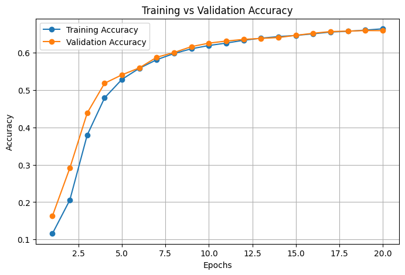

```python
#let's plot the training and validation accuracies
acc = history1.history['accuracy']
val_acc = history1.history['val_accuracy']
epochs = range(1, len(acc) + 1)


plt.figure(figsize=(8, 5))
plt.plot(epochs, acc, label='Training Accuracy', marker='o')
plt.plot(epochs, val_acc, label='Validation Accuracy', marker='o')
plt.title('Training vs Validation Accuracy')
plt.xlabel('Epochs')
plt.ylabel('Accuracy')
plt.legend()
plt.grid(True)
plt.show()
```

```python
# let's evaluate our model1
test_loss, test_accuracy = model1.evaluate(X_test_ann, y_test_oh, verbose=1)

print(f"\nTest Accuracy: {test_accuracy:.4f}")
print(f"Test Loss: {test_loss:.4f}")
```

```
563/563 ━━━━━━━━━━━━━━━━━━━━ 1s 1ms/step - accuracy: 0.6719 - loss: 1.0674

Test Accuracy: 0.6673
Test Loss: 1.0909
```

```python
#let's predict the class probabilities for each input sample in the test data
y_pred_probs = model1.predict(X_test_ann)
#let's convert the probability vectors into actual class labels by picking the index with the highest probability
y_pred_classes = np.argmax(y_pred_probs, axis=1)
#let's convert our one-hot encoded test labels into actual class labels (integers from 0 to 9), so we can compare them to the predictions
y_true_classes = np.argmax(y_test_oh, axis=1)
```

```
563/563 ━━━━━━━━━━━━━━━━━━━━ 1s 980us/step
```

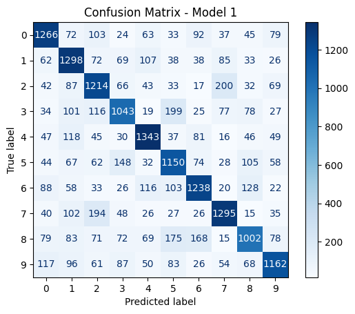

```python
# let's plot the confusion matrix for model1
cm = confusion_matrix(y_true_classes, y_pred_classes)
plt.figure(figsize=(8, 6))
disp = ConfusionMatrixDisplay(confusion_matrix=cm, display_labels=range(10))
disp.plot(cmap=plt.cm.Blues, values_format='d')
plt.title("Confusion Matrix - Model 1")
plt.show()
```

**Observations:**

Our first ANN model1 achieved around 67% accuracy on the test dataset, which means it correctly predicted about two-thirds of the digits.

While this shows the model has learned meaningful patterns, there is still considerable room for improvement. The loss value around 1.09 indicates the model’s predictions are not yet very confident or precise for every class.

This is a decent starting point for a simple ANN, but we might get better performance using more advanced architectures like CNNs that can better capture the spatial features of images.

The confusion matrix shows how well the model predicted each digit from 0 to 9 on the test data.

Most of the numbers are correctly identified, as seen by the strong diagonal of high values. This means the model is quite good at recognising digits accurately.

However, there are some off-diagonal values, which indicate where the model confused one digit for another. For example, it might mix up digits like 3 and 8 or 5 and 6 in some cases.

Overall, the matrix suggests the model performs well but has room to improve in distinguishing similar-looking digits.

Let's build one more model with higher complexity and see if we can improve the performance of the model.

First, we need to clear the previous model's history from the Keras backend. Also, let's fix the seed again after clearing the backend.

```python
# let's clear Keras backend session to free memory and reset
K.clear_session()

# And reset seeds for reproducibility
seed = 36 #as we said before, this can be a random number
random.seed(seed)
np.random.seed(seed)
tf.random.set_seed(seed)
```

### **Second Model Architecture**

- Write a function that returns a sequential model with the following architecture:
- First hidden layer with **256 nodes and the relu activation** and the **input shape = (1024, )**
- Second hidden layer with **128 nodes and the relu activation**
- Add the **Dropout layer with the rate equal to 0.2**
- Third hidden layer with **64 nodes and the relu activation**
- Fourth hidden layer with **64 nodes and the relu activation**
- Fifth hidden layer with **32 nodes and the relu activation**
- Add the **BatchNormalization layer**
- Output layer with **activation as 'softmax' and number of nodes equal to the number of classes, i.e., 10** -Compile the model with the **loss equal to categorical_crossentropy, optimizer equal to Adam(learning_rate = 0.0005), and metric equal to 'accuracy'**. Do not fit the model here, just return the compiled model.
- Call the nn_model_2 function and store the model in a new variable.
- Print the summary of the model.
- Fit on the train data with a **validation split of 0.2, batch size = 128, verbose = 1, and epochs = 30**. Store the model building history to use later for visualization.

### **Build and train the new ANN model as per the above mentioned architecture**

```python
# let's build our second model
def nn_model_2():
    model = Sequential()
    model.add(Dense(256, activation='relu', input_shape=(1024,)))
    model.add(Dense(128, activation='relu'))
    model.add(Dropout(0.2))
    model.add(Dense(64, activation='relu'))
    model.add(Dense(64, activation='relu'))
    model.add(Dense(32, activation='relu'))
    model.add(BatchNormalization())
    model.add(Dense(10, activation='softmax'))

    model.compile(
        loss='categorical_crossentropy',
        optimizer=Adam(learning_rate=0.0005),
        metrics=['accuracy']
    )

    return model
```

```python
model2 = nn_model_2()
```

```python
history2 = model2.fit(
    X_train_ann,
    y_train_oh,
    validation_split=0.2,
    batch_size=128,
    epochs=30,
    verbose=1
)
```

```
263/263 ━━━━━━━━━━━━━━━━━━━━ 5s 11ms/step - accuracy: 0.1005 - loss: 2.4734 - val_accuracy: 0.0969 - val_loss: 2.3177
263/263 ━━━━━━━━━━━━━━━━━━━━ 3s 10ms/step - accuracy: 0.1117 - loss: 2.3051 - val_accuracy: 0.1889 - val_loss: 2.2530
263/263 ━━━━━━━━━━━━━━━━━━━━ 3s 10ms/step - accuracy: 0.2688 - loss: 2.0309 - val_accuracy: 0.4074 - val_loss: 1.7327
263/263 ━━━━━━━━━━━━━━━━━━━━ 3s 9ms/step - accuracy: 0.4799 - loss: 1.5304 - val_accuracy: 0.5827 - val_loss: 1.2792
263/263 ━━━━━━━━━━━━━━━━━━━━ 3s 9ms/step - accuracy: 0.5640 - loss: 1.3189 - val_accuracy: 0.6117 - val_loss: 1.2009
263/263 ━━━━━━━━━━━━━━━━━━━━ 3s 9ms/step - accuracy: 0.6169 - loss: 1.1803 - val_accuracy: 0.6543 - val_loss: 1.0786
263/263 ━━━━━━━━━━━━━━━━━━━━ 3s 10ms/step - accuracy: 0.6455 - loss: 1.1044 - val_accuracy: 0.6752 - val_loss: 1.0263
263/263 ━━━━━━━━━━━━━━━━━━━━ 3s 10ms/step - accuracy: 0.6610 - loss: 1.0617 - val_accuracy: 0.6826 - val_loss: 1.0107
263/263 ━━━━━━━━━━━━━━━━━━━━ 3s 9ms/step - accuracy: 0.6704 - loss: 1.0175 - val_accuracy: 0.7154 - val_loss: 0.9309
263/263 ━━━━━━━━━━━━━━━━━━━━ 3s 10ms/step - accuracy: 0.6857 - loss: 0.9857 - val_accuracy: 0.7183 - val_loss: 0.8987
263/263 ━━━━━━━━━━━━━━━━━━━━ 3s 9ms/step - accuracy: 0.6955 - loss: 0.9561 - val_accuracy: 0.7198 - val_loss: 0.8932
263/263 ━━━━━━━━━━━━━━━━━━━━ 3s 9ms/step - accuracy: 0.7055 - loss: 0.9279 - val_accuracy: 0.7210 - val_loss: 0.8899
263/263 ━━━━━━━━━━━━━━━━━━━━ 3s 10ms/step - accuracy: 0.7128 - loss: 0.9035 - val_accuracy: 0.7335 - val_loss: 0.8653
263/263 ━━━━━━━━━━━━━━━━━━━━ 2s 9ms/step - accuracy: 0.7189 - loss: 0.8816 - val_accuracy: 0.7257 - val_loss: 0.8727
263/263 ━━━━━━━━━━━━━━━━━━━━ 3s 9ms/step - accuracy: 0.7302 - loss: 0.8546 - val_accuracy: 0.7298 - val_loss: 0.8777
263/263 ━━━━━━━━━━━━━━━━━━━━ 2s 9ms/step - accuracy: 0.7300 - loss: 0.8492 - val_accuracy: 0.7351 - val_loss: 0.8373
263/263 ━━━━━━━━━━━━━━━━━━━━ 3s 9ms/step - accuracy: 0.7278 - loss: 0.8570 - val_accuracy: 0.7408 - val_loss: 0.8313
263/263 ━━━━━━━━━━━━━━━━━━━━ 3s 9ms/step - accuracy: 0.7391 - loss: 0.8304 - val_accuracy: 0.7483 - val_loss: 0.8061
263/263 ━━━━━━━━━━━━━━━━━━━━ 3s 9ms/step - accuracy: 0.7379 - loss: 0.8186 - val_accuracy: 0.7394 - val_loss: 0.8335
263/263 ━━━━━━━━━━━━━━━━━━━━ 3s 10ms/step - accuracy: 0.7464 - loss: 0.8007 - val_accuracy: 0.7520 - val_loss: 0.7993
263/263 ━━━━━━━━━━━━━━━━━━━━ 3s 10ms/step - accuracy: 0.7504 - loss: 0.7890 - val_accuracy: 0.7529 - val_loss: 0.7902
263/263 ━━━━━━━━━━━━━━━━━━━━ 3s 10ms/step - accuracy: 0.7509 - loss: 0.7789 - val_accuracy: 0.7499 - val_loss: 0.8012
263/263 ━━━━━━━━━━━━━━━━━━━━ 3s 10ms/step - accuracy: 0.7572 - loss: 0.7699 - val_accuracy: 0.7624 - val_loss: 0.7700
263/263 ━━━━━━━━━━━━━━━━━━━━ 3s 10ms/step - accuracy: 0.7551 - loss: 0.7645 - val_accuracy: 0.7520 - val_loss: 0.7934
263/263 ━━━━━━━━━━━━━━━━━━━━ 3s 9ms/step - accuracy: 0.7559 - loss: 0.7639 - val_accuracy: 0.7582 - val_loss: 0.7771
263/263 ━━━━━━━━━━━━━━━━━━━━ 3s 10ms/step - accuracy: 0.7649 - loss: 0.7423 - val_accuracy: 0.7651 - val_loss: 0.7616
263/263 ━━━━━━━━━━━━━━━━━━━━ 3s 9ms/step - accuracy: 0.7637 - loss: 0.7397 - val_accuracy: 0.7546 - val_loss: 0.7788
263/263 ━━━━━━━━━━━━━━━━━━━━ 3s 10ms/step - accuracy: 0.7655 - loss: 0.7321 - val_accuracy: 0.7483 - val_loss: 0.7950
263/263 ━━━━━━━━━━━━━━━━━━━━ 3s 9ms/step - accuracy: 0.7642 - loss: 0.7320 - val_accuracy: 0.7673 - val_loss: 0.7548
263/263 ━━━━━━━━━━━━━━━━━━━━ 3s 10ms/step - accuracy: 0.7685 - loss: 0.7295 - val_accuracy: 0.7611 - val_loss: 0.7677
```

```python
model2.summary()
```

```
Model: "sequential"
```

```
┏━━━━━━━━━━━━━━━━━━━━━━━━━━━━━━━━━┳━━━━━━━━━━━━━━━━━━━━━━━━┳━━━━━━━━━━━━━━━┓
┃ Layer (type)                    ┃ Output Shape           ┃       Param # ┃
┡━━━━━━━━━━━━━━━━━━━━━━━━━━━━━━━━━╇━━━━━━━━━━━━━━━━━━━━━━━━╇━━━━━━━━━━━━━━━┩
│ dense (Dense)                   │ (None, 256)            │       262,400 │
├─────────────────────────────────┼────────────────────────┼───────────────┤
│ dense_1 (Dense)                 │ (None, 128)            │        32,896 │
├─────────────────────────────────┼────────────────────────┼───────────────┤
│ dropout (Dropout)               │ (None, 128)            │             0 │
├─────────────────────────────────┼────────────────────────┼───────────────┤
│ dense_2 (Dense)                 │ (None, 64)             │         8,256 │
├─────────────────────────────────┼────────────────────────┼───────────────┤
│ dense_3 (Dense)                 │ (None, 64)             │         4,160 │
├─────────────────────────────────┼────────────────────────┼───────────────┤
│ dense_4 (Dense)                 │ (None, 32)             │         2,080 │
├─────────────────────────────────┼────────────────────────┼───────────────┤
│ batch_normalization             │ (None, 32)             │           128 │
│ (BatchNormalization)            │                        │               │
├─────────────────────────────────┼────────────────────────┼───────────────┤
│ dense_5 (Dense)                 │ (None, 10)             │           330 │
└─────────────────────────────────┴────────────────────────┴───────────────┘
```

```
 Total params: 930,624 (3.55 MB)
```

```
 Trainable params: 310,186 (1.18 MB)
```

```
 Non-trainable params: 64 (256.00 B)
```

```
 Optimizer params: 620,374 (2.37 MB)
```

### **Plot the Training and Validation Accuracies and write down your Observations.**

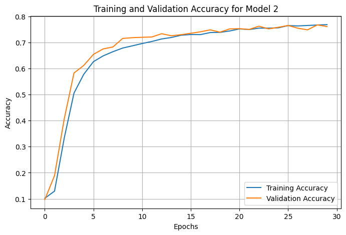

```python
plt.figure(figsize=(8,5))
plt.plot(history2.history['accuracy'], label='Training Accuracy')
plt.plot(history2.history['val_accuracy'], label='Validation Accuracy')
plt.title('Training and Validation Accuracy for Model 2')
plt.xlabel('Epochs')
plt.ylabel('Accuracy')
plt.legend()
plt.grid(True)
plt.show()
```

```python
test_loss, test_accuracy = model2.evaluate(X_test_ann, y_test_oh, verbose=1)
print(f"Test Accuracy: {test_accuracy:.4f}")
print(f"Test Loss: {test_loss:.4f}")
```

```
563/563 ━━━━━━━━━━━━━━━━━━━━ 1s 2ms/step - accuracy: 0.7645 - loss: 0.7568
Test Accuracy: 0.7581
Test Loss: 0.7772
```

**Observations:**

Our second neural network model showed noticeable improvements over earlier attempts. Its architecture consisted of five hidden dense layers with gradually decreasing node sizes (from 256 to 32), ReLU activations, dropout (0.2), and batch normalisation before the final softmax output. The model was trained over 30 epochs with a batch size of 128 and an Adam optimiser using a lower learning rate of 0.0005.

Training and validation accuracies increased, reaching around 76.9% and 76.1%, respectively, by the final epoch, indicating good learning without overfitting. The model achieved a test accuracy of 75.8%, which aligns well with the validation performance, suggesting decent generalisation. Loss values also decreased consistently, with final test loss around 0.77.

This model benefits from deeper architecture and regularisation (dropout + batch normalisation), contributing to improved stability and generalisation. However, there's still room for enhancement, especially in improving class-wise precision and pushing accuracy further.

## **Predictions on the test data**

- Make predictions on the test set using the second model.
- Print the obtained results using the classification report and the confusion matrix.
- Final observations on the obtained results.

```python
y_true_labels = np.argmax(y_test_oh, axis=1)
y_pred_probs = model2.predict(X_test_ann)
y_pred_labels = np.argmax(y_pred_probs, axis=1)
```

```
563/563 ━━━━━━━━━━━━━━━━━━━━ 1s 1ms/step
```

**Note:** Earlier, we noticed that each entry of the target variable is a one-hot encoded vector but to print the classification report and confusion matrix, we must convert each entry of y_test to a single label.

### **Print the classification report and the confusion matrix for the test predictions. Write your observations on the final results.**

```python
# let's see our classification report for model 2
report = classification_report(y_true_labels, y_pred_labels)
print(report)
```

```
              precision    recall  f1-score   support

           0       0.74      0.81      0.77      1814
           1       0.73      0.83      0.78      1828
           2       0.78      0.77      0.77      1803
           3       0.78      0.68      0.73      1719
           4       0.80      0.83      0.81      1812
           5       0.75      0.68      0.71      1768
           6       0.74      0.78      0.76      1832
           7       0.88      0.71      0.78      1808
           8       0.63      0.78      0.70      1812
           9       0.83      0.70      0.76      1804

    accuracy                           0.76     18000
   macro avg       0.77      0.76      0.76     18000
weighted avg       0.77      0.76      0.76     18000
```

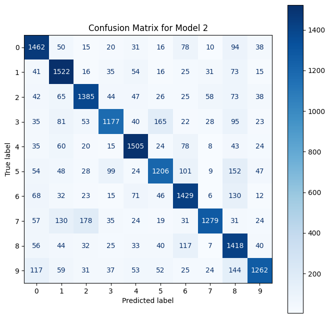

```python
cm = confusion_matrix(y_true, y_pred)
disp = ConfusionMatrixDisplay(confusion_matrix=cm, display_labels=range(10))
fig, ax = plt.subplots(figsize=(8,8))
disp.plot(ax=ax, cmap=plt.cm.Blues)
plt.title("Confusion Matrix for Model 2")
plt.show()
```

**Final Observations:**

Our second model demonstrated well overall performance, achieving a test accuracy of 76%, which aligns closely with its validation accuracy and confirms the model’s ability to generalise reasonably well to unseen data. The classification report highlights consistent performance across most classes, with macro and weighted F1-scores of 0.76, indicating balanced precision and recall.

Class-wise, the model performs well on digits such as 0, 1, 2, and 4, achieving F1-scores around 0.77–0.81. However, slightly weaker results are observed for classes 5, 7, 8, and 9, where either precision or recall drops below 0.75. Notably, class 8 achieves only 0.63 precision, suggesting confusion with visually similar digits. The model benefits from its deeper architecture, regularisation via dropout and batch normalisation, and a tuned learning rate, which likely contribute to its stability during training.

In conclusion, while the model shows strong performance and consistent accuracy across digits, it could be improved to target class, possibly through data augmentation, fine-tuning the architecture further, or incorporating more advanced regularisation and ensemble techniques.

## **Using Convolutional Neural Networks**

### **Load the dataset again and split the data into the train and the test dataset.**

```python
print(X_train.shape)
```

```
(42000, 32, 32)
```

```python
print(X_train.dtype)
print(X_train.min(), X_train.max())
```

```
float32
0.0 254.9745
```

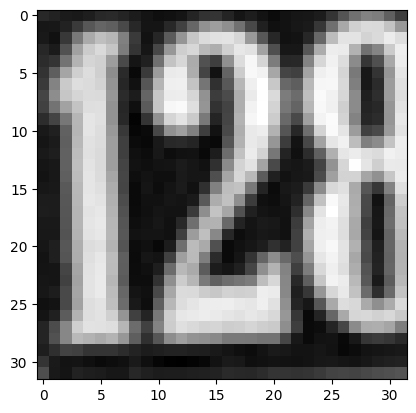

```python
plt.imshow(X_train[0], cmap='gray')
plt.show()
```

```python
# let's list all variables in our workspace
%whos
```

[output not shown]

[output cut: 36 more lines]

[output not shown]

```python
print("Train labels shape:", y_train.shape)
print("Test labels shape:", y_test.shape)
print("Validation labels shape:", y_val.shape)

print("Unique classes in train:", np.unique(y_train))
print("Unique classes in test:", np.unique(y_test))
print("Unique classes in val:", np.unique(y_val))
```

```
Train labels shape: (42000,)
Test labels shape: (18000,)
Validation labels shape: (60000,)
Unique classes in train: [0 1 2 3 4 5 6 7 8 9]
Unique classes in test: [0 1 2 3 4 5 6 7 8 9]
Unique classes in val: [0 1 2 3 4 5 6 7 8 9]
```

Check the number of images in the training and the testing dataset.

```python
print("Number of training images:", X_train.shape[0])
print("Number of validation images:", X_val.shape[0])
print("Number of testing images:", X_test.shape[0])
```

```
Number of training images: 42000
Number of validation images: 60000
Number of testing images: 18000
```

**Observation:**

This third model will be trained on 42,000 images, with validation and testing done on 60,000 and 18,000 images, respectively. All three datasets include samples from all 10 digit classes (0 to 9), so the data is well-balanced across splits. Having a large validation set should help with monitoring the model's generalisation during training, and the consistent class distribution makes it easier to assess the model’s overall and per-class performance after training.

## **Data preparation**

- Print the shape and the array of pixels for the first image in the training dataset.
- Reshape the train and the test dataset because we always have to give a 4D array as input to CNNs.
- Normalize the train and the test dataset by dividing by 255.
- Print the new shapes of the train and the test dataset.
- One-hot encode the target variable.

```python
print("Shape of first training image:", X_train[0].shape)
print("Pixel array of first training image:\n", X_train[0])
```

```
Shape of first training image: (32, 32)
Pixel array of first training image:
 [[ 33.0704  30.2601  26.852  ...  71.4471  58.2204  42.9939]
 [ 25.2283  25.5533  29.9765 ... 113.0209 103.3639  84.2949]
 [ 26.2775  22.6137  40.4763 ... 113.3028 121.775  115.4228]
 ...
 [ 28.5502  36.212   45.0801 ...  24.1359  25.0927  26.0603]
 [ 38.4352  26.4733  23.2717 ...  28.1094  29.4683  30.0661]
 [ 50.2984  26.0773  24.0389 ...  49.6682  50.853   53.0377]]
```

Reshape the dataset to be able to pass them to CNNs. Remember that we always have to give a 4D array as input to CNNs

```python
X_train = X_train.reshape(-1, 32, 32, 1)
X_test = X_test.reshape(-1, 32, 32, 1)
```

Normalize inputs from 0-255 to 0-1

```python
X_train = X_train / 255.0
X_test = X_test / 255.0
```

Print New shape of Training and Test

```python
print("New shape of X_train:", X_train.shape)
print("New shape of X_test:", X_test.shape)
```

```
New shape of X_train: (42000, 32, 32, 1)
New shape of X_test: (18000, 32, 32, 1)
```

### **One-hot encode the labels in the target variable y_train and y_test.**

```python
y_train_oh = to_categorical(y_train, num_classes=10)
y_test_oh = to_categorical(y_test, num_classes=10)

print("Shape of one-hot encoded y_train:", y_train_oh.shape)
print("Shape of one-hot encoded y_test:", y_test_oh.shape)
```

```
Shape of one-hot encoded y_train: (42000, 10)
Shape of one-hot encoded y_test: (18000, 10)
```

**Observation:**

The image data has been successfully prepared for convolutional neural networks, with each image reshaped to a 32x32 pixel format and a single grayscale channel, resulting in input shapes of (42000, 32, 32, 1) for training and (18000, 32, 32, 1) for testing.

Pixel values have been normalised to the [0, 1] range to improve model convergence and stability during training. The target labels have been one-hot encoded into vectors of length 10, matching the number of classes, which facilitates multi-class classification with categorical cross-entropy loss.

This preprocessing aligns well with CNN best practices and sets a solid foundation for building a robust model.

## **Model Building**

Now that we have done data preprocessing, let's build a CNN model. Fix the seed for random number generators

```python
seed_value = 36
random.seed(seed_value)
np.random.seed(seed_value)
tf.random.set_seed(seed_value)
```

### **Model Architecture**

- **Write a function** that returns a sequential model with the following architecture:
- First Convolutional layer with **16 filters and the kernel size of 3x3**. Use the **'same' padding** and provide the **input shape = (32, 32, 1)**
- Add a **LeakyRelu layer** with the **slope equal to 0.1**
- Second Convolutional layer with **32 filters and the kernel size of 3x3 with 'same' padding**
- Another **LeakyRelu** with the **slope equal to 0.1**
- A **max-pooling layer** with a **pool size of 2x2**
- **Flatten** the output from the previous layer
- Add a **dense layer with 32 nodes**
- Add a **LeakyRelu layer with the slope equal to 0.1**
- Add the final **output layer with nodes equal to the number of classes, i.e., 10** and **'softmax' as the activation function**
- Compile the model with the **loss equal to categorical_crossentropy, optimizer equal to Adam(learning_rate = 0.001), and metric equal to 'accuracy'**. Do not fit the model here, just return the compiled model.
- Call the function cnn_model_1 and store the output in a new variable.
- Print the summary of the model.
- Fit the model on the training data with a **validation split of 0.2, batch size = 32, verbose = 1, and epochs = 20**. Store the model building history to use later for visualization.

### **Build and train a CNN model as per the above mentioned architecture.**

```python
#let's build our third model
def cnn_model_1(input_shape=(32, 32, 1), num_classes=10):
    model = Sequential()
    model.add(Conv2D(16, kernel_size=(3, 3), padding='same', input_shape=input_shape))
    model.add(LeakyReLU(alpha=0.1))
    model.add(Conv2D(32, kernel_size=(3, 3), padding='same'))
    model.add(LeakyReLU(alpha=0.1))
    model.add(MaxPooling2D(pool_size=(2, 2)))
    model.add(Flatten())
    model.add(Dense(32))
    model.add(LeakyReLU(alpha=0.1))
    model.add(Dense(num_classes, activation='softmax'))

    model.compile(
    loss='categorical_crossentropy',
    optimizer=Adam(learning_rate=0.001),
    metrics=['accuracy']
)
    return model
```

```python
# we rename the model
model3 = cnn_model_1()
```

```python
# and fit the model
history = model3.fit(
    X_train, y_train_oh,   # your normalized train data and one-hot encoded labels
    validation_split=0.2,
    batch_size=32,
    epochs=20,
    verbose=1
)
```

```
1050/1050 ━━━━━━━━━━━━━━━━━━━━ 52s 48ms/step - accuracy: 0.5167 - loss: 1.4288 - val_accuracy: 0.8375 - val_loss: 0.5764
1050/1050 ━━━━━━━━━━━━━━━━━━━━ 47s 45ms/step - accuracy: 0.8322 - loss: 0.5785 - val_accuracy: 0.8449 - val_loss: 0.5378
1050/1050 ━━━━━━━━━━━━━━━━━━━━ 47s 45ms/step - accuracy: 0.8607 - loss: 0.4858 - val_accuracy: 0.8494 - val_loss: 0.5298
1050/1050 ━━━━━━━━━━━━━━━━━━━━ 47s 45ms/step - accuracy: 0.8783 - loss: 0.4207 - val_accuracy: 0.8598 - val_loss: 0.5006
1050/1050 ━━━━━━━━━━━━━━━━━━━━ 47s 45ms/step - accuracy: 0.8925 - loss: 0.3704 - val_accuracy: 0.8575 - val_loss: 0.5136
1050/1050 ━━━━━━━━━━━━━━━━━━━━ 47s 45ms/step - accuracy: 0.9041 - loss: 0.3302 - val_accuracy: 0.8574 - val_loss: 0.5304
1050/1050 ━━━━━━━━━━━━━━━━━━━━ 47s 45ms/step - accuracy: 0.9156 - loss: 0.2936 - val_accuracy: 0.8593 - val_loss: 0.5453
1050/1050 ━━━━━━━━━━━━━━━━━━━━ 47s 45ms/step - accuracy: 0.9258 - loss: 0.2613 - val_accuracy: 0.8565 - val_loss: 0.5800
1050/1050 ━━━━━━━━━━━━━━━━━━━━ 47s 45ms/step - accuracy: 0.9306 - loss: 0.2337 - val_accuracy: 0.8431 - val_loss: 0.6666
1050/1050 ━━━━━━━━━━━━━━━━━━━━ 47s 45ms/step - accuracy: 0.9414 - loss: 0.2073 - val_accuracy: 0.8560 - val_loss: 0.6600
1050/1050 ━━━━━━━━━━━━━━━━━━━━ 47s 45ms/step - accuracy: 0.9442 - loss: 0.1918 - val_accuracy: 0.8518 - val_loss: 0.6866
1050/1050 ━━━━━━━━━━━━━━━━━━━━ 47s 45ms/step - accuracy: 0.9492 - loss: 0.1717 - val_accuracy: 0.8433 - val_loss: 0.7777
1050/1050 ━━━━━━━━━━━━━━━━━━━━ 47s 45ms/step - accuracy: 0.9535 - loss: 0.1535 - val_accuracy: 0.8529 - val_loss: 0.7489
1050/1050 ━━━━━━━━━━━━━━━━━━━━ 47s 45ms/step - accuracy: 0.9575 - loss: 0.1393 - val_accuracy: 0.8598 - val_loss: 0.7458
1050/1050 ━━━━━━━━━━━━━━━━━━━━ 47s 44ms/step - accuracy: 0.9597 - loss: 0.1282 - val_accuracy: 0.8486 - val_loss: 0.8600
1050/1050 ━━━━━━━━━━━━━━━━━━━━ 47s 45ms/step - accuracy: 0.9641 - loss: 0.1154 - val_accuracy: 0.8525 - val_loss: 0.8709
1050/1050 ━━━━━━━━━━━━━━━━━━━━ 46s 44ms/step - accuracy: 0.9659 - loss: 0.1087 - val_accuracy: 0.8540 - val_loss: 0.8756
1050/1050 ━━━━━━━━━━━━━━━━━━━━ 47s 45ms/step - accuracy: 0.9697 - loss: 0.0947 - val_accuracy: 0.8471 - val_loss: 0.9907
1050/1050 ━━━━━━━━━━━━━━━━━━━━ 47s 45ms/step - accuracy: 0.9690 - loss: 0.0942 - val_accuracy: 0.8617 - val_loss: 0.9523
1050/1050 ━━━━━━━━━━━━━━━━━━━━ 47s 45ms/step - accuracy: 0.9679 - loss: 0.0977 - val_accuracy: 0.8656 - val_loss: 0.9498
```

```python
# let's see the model summary
model3.summary()
```

```
Model: "sequential_2"
```

```
┏━━━━━━━━━━━━━━━━━━━━━━━━━━━━━━━━━┳━━━━━━━━━━━━━━━━━━━━━━━━┳━━━━━━━━━━━━━━━┓
┃ Layer (type)                    ┃ Output Shape           ┃       Param # ┃
┡━━━━━━━━━━━━━━━━━━━━━━━━━━━━━━━━━╇━━━━━━━━━━━━━━━━━━━━━━━━╇━━━━━━━━━━━━━━━┩
│ conv2d_4 (Conv2D)               │ (None, 32, 32, 16)     │           160 │
├─────────────────────────────────┼────────────────────────┼───────────────┤
│ leaky_re_lu_6 (LeakyReLU)       │ (None, 32, 32, 16)     │             0 │
├─────────────────────────────────┼────────────────────────┼───────────────┤
│ conv2d_5 (Conv2D)               │ (None, 32, 32, 32)     │         4,640 │
├─────────────────────────────────┼────────────────────────┼───────────────┤
│ leaky_re_lu_7 (LeakyReLU)       │ (None, 32, 32, 32)     │             0 │
├─────────────────────────────────┼────────────────────────┼───────────────┤
│ max_pooling2d_2 (MaxPooling2D)  │ (None, 16, 16, 32)     │             0 │
├─────────────────────────────────┼────────────────────────┼───────────────┤
│ flatten_2 (Flatten)             │ (None, 8192)           │             0 │
├─────────────────────────────────┼────────────────────────┼───────────────┤
│ dense_4 (Dense)                 │ (None, 32)             │       262,176 │
├─────────────────────────────────┼────────────────────────┼───────────────┤
│ leaky_re_lu_8 (LeakyReLU)       │ (None, 32)             │             0 │
├─────────────────────────────────┼────────────────────────┼───────────────┤
│ dense_5 (Dense)                 │ (None, 10)             │           330 │
└─────────────────────────────────┴────────────────────────┴───────────────┘
```

```
 Total params: 801,920 (3.06 MB)
```

```
 Trainable params: 267,306 (1.02 MB)
```

```
 Non-trainable params: 0 (0.00 B)
```

```
 Optimizer params: 534,614 (2.04 MB)
```

### **Plot the Training and Validation Accuracies and Write your observations.**

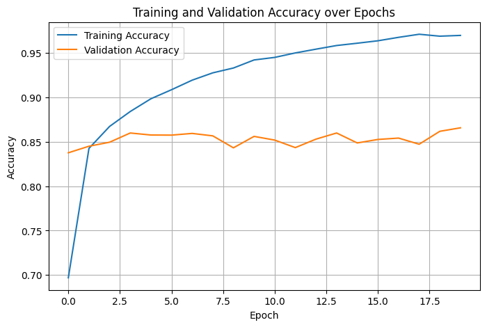

```python
plt.figure(figsize=(8,5))
plt.plot(history.history['accuracy'], label='Training Accuracy')
plt.plot(history.history['val_accuracy'], label='Validation Accuracy')
plt.title('Training and Validation Accuracy over Epochs')
plt.xlabel('Epoch')
plt.ylabel('Accuracy')
plt.legend()
plt.grid(True)
plt.show()
```

**Observations:**

Our third model, a CNN model, was built with two convolutional layers using 16 and 32 filters respectively, both followed by LeakyReLU activations with a slope of 0.1, which helps prevent the dying ReLU problem.

After the convolutions, a max-pooling layer reduces the spatial dimensions, followed by flattening and a dense layer of 32 nodes before the final output layer of 10 classes with softmax activation. The model was compiled with the Adam optimiser and categorical cross-entropy loss.

During training over 20 epochs, the model showed a rapid increase in training accuracy, reaching over 96%, while validation accuracy stabilised around 85–86%. Interestingly, the validation accuracy peaked at about epoch 20 with 86.56%, but the **validation loss started increasing** from around epoch 9, indicating some overfitting as the model became too specialised on the training data. The total number of parameters was just over 267k, making the model relatively lightweight and suitable for this task.

Overall, the model performed well, achieving good accuracy and showing solid learning behaviour, but could potentially benefit from regularisation or early stopping to avoid overfitting and improve generalisation on unseen data.

Suggestions for model improving:

- Adding dropout layers
- Using data augmentation
- Early stopping
- Reducing model complexity
- Tuning hyperparameters (learning rate, batch size)

Let's build another model and see if we can get a better model with generalized performance.

First, we need to clear the previous model's history from the Keras backend. Also, let's fix the seed again after clearing the backend.

```python
K.clear_session()
seed = 36
np.random.seed(seed)
random.seed(seed)
tf.random.set_seed(seed)
```

### **Second Model Architecture**

- Write a function that returns a sequential model with the following architecture:
- First Convolutional layer with **16 filters and the kernel size of 3x3**. Use the **'same' padding** and provide the **input shape = (32, 32, 1)**
- Add a **LeakyRelu layer** with the **slope equal to 0.1**
- Second Convolutional layer with **32 filters and the kernel size of 3x3 with 'same' padding**
- Add **LeakyRelu** with the **slope equal to 0.1**
- Add a **max-pooling layer** with a **pool size of 2x2**
- Add a **BatchNormalization layer**
- Third Convolutional layer with **32 filters and the kernel size of 3x3 with 'same' padding**
- Add a **LeakyRelu layer with the slope equal to 0.1**
- Fourth Convolutional layer **64 filters and the kernel size of 3x3 with 'same' padding**
- Add a **LeakyRelu layer with the slope equal to 0.1**
- Add a **max-pooling layer** with a **pool size of 2x2**
- Add a **BatchNormalization layer**
- **Flatten** the output from the previous layer
- Add a **dense layer with 32 nodes**
- Add a **LeakyRelu layer with the slope equal to 0.1**
- Add a **dropout layer with the rate equal to 0.5**
- Add the final **output layer with nodes equal to the number of classes, i.e., 10** and **'softmax' as the activation function**
- Compile the model with the **categorical_crossentropy loss, adam optimizers (learning_rate = 0.001), and metric equal to 'accuracy'**. Do not fit the model here, just return the compiled model.
- Call the function cnn_model_2 and store the model in a new variable.
- Print the summary of the model.
- Fit the model on the train data with a **validation split of 0.2, batch size = 128, verbose = 1, and epochs = 30**. Store the model building history to use later for visualization.

### **Build and train the second CNN model as per the above mentioned architecture.**

```python
# let's build our fourth model
def cnn_model_2(input_shape=(32, 32, 1), num_classes=10):
    model = Sequential()
    model.add(Conv2D(16, kernel_size=(3, 3), padding='same', input_shape=input_shape))
    model.add(LeakyReLU(alpha=0.1))
    model.add(Conv2D(32, kernel_size=(3, 3), padding='same'))
    model.add(LeakyReLU(alpha=0.1))
    model.add(MaxPooling2D(pool_size=(2, 2)))
    model.add(BatchNormalization())
    model.add(Conv2D(32, kernel_size=(3, 3), padding='same'))
    model.add(LeakyReLU(alpha=0.1))
    model.add(Conv2D(64, kernel_size=(3, 3), padding='same'))
    model.add(LeakyReLU(alpha=0.1))
    model.add(MaxPooling2D(pool_size=(2, 2)))
    model.add(BatchNormalization())
    model.add(Flatten())
    model.add(Dense(32))
    model.add(LeakyReLU(alpha=0.1))
    model.add(Dropout(0.5))
    model.add(Dense(num_classes, activation='softmax'))

    model.compile(
        loss='categorical_crossentropy',
        optimizer=Adam(learning_rate=0.001),
        metrics=['accuracy']
    )

    return model
```

```python
model4 = cnn_model_2()
```

```python
history4 = model4.fit(
    X_train, y_train_oh,
    validation_split=0.2,
    batch_size=128,
    epochs=30,
    verbose=1
)
```

```
263/263 ━━━━━━━━━━━━━━━━━━━━ 102s 378ms/step - accuracy: 0.3064 - loss: 1.9809 - val_accuracy: 0.2685 - val_loss: 1.8912
263/263 ━━━━━━━━━━━━━━━━━━━━ 99s 377ms/step - accuracy: 0.7841 - loss: 0.7200 - val_accuracy: 0.8531 - val_loss: 0.4997
263/263 ━━━━━━━━━━━━━━━━━━━━ 99s 377ms/step - accuracy: 0.8266 - loss: 0.5762 - val_accuracy: 0.8643 - val_loss: 0.4628
263/263 ━━━━━━━━━━━━━━━━━━━━ 97s 368ms/step - accuracy: 0.8477 - loss: 0.5040 - val_accuracy: 0.8817 - val_loss: 0.4133
263/263 ━━━━━━━━━━━━━━━━━━━━ 96s 365ms/step - accuracy: 0.8598 - loss: 0.4545 - val_accuracy: 0.8652 - val_loss: 0.4560
263/263 ━━━━━━━━━━━━━━━━━━━━ 97s 367ms/step - accuracy: 0.8724 - loss: 0.4132 - val_accuracy: 0.8961 - val_loss: 0.3748
263/263 ━━━━━━━━━━━━━━━━━━━━ 98s 374ms/step - accuracy: 0.8838 - loss: 0.3794 - val_accuracy: 0.8919 - val_loss: 0.3762
263/263 ━━━━━━━━━━━━━━━━━━━━ 99s 375ms/step - accuracy: 0.8924 - loss: 0.3542 - val_accuracy: 0.8933 - val_loss: 0.3938
263/263 ━━━━━━━━━━━━━━━━━━━━ 98s 373ms/step - accuracy: 0.8955 - loss: 0.3261 - val_accuracy: 0.9012 - val_loss: 0.3693
263/263 ━━━━━━━━━━━━━━━━━━━━ 97s 368ms/step - accuracy: 0.9027 - loss: 0.3070 - val_accuracy: 0.8767 - val_loss: 0.4528
263/263 ━━━━━━━━━━━━━━━━━━━━ 97s 369ms/step - accuracy: 0.9036 - loss: 0.3003 - val_accuracy: 0.9005 - val_loss: 0.4006
263/263 ━━━━━━━━━━━━━━━━━━━━ 98s 371ms/step - accuracy: 0.9133 - loss: 0.2737 - val_accuracy: 0.8865 - val_loss: 0.4510
263/263 ━━━━━━━━━━━━━━━━━━━━ 97s 368ms/step - accuracy: 0.9152 - loss: 0.2661 - val_accuracy: 0.8854 - val_loss: 0.4196
263/263 ━━━━━━━━━━━━━━━━━━━━ 99s 376ms/step - accuracy: 0.9188 - loss: 0.2568 - val_accuracy: 0.9058 - val_loss: 0.3891
263/263 ━━━━━━━━━━━━━━━━━━━━ 97s 368ms/step - accuracy: 0.9199 - loss: 0.2463 - val_accuracy: 0.9036 - val_loss: 0.3891
263/263 ━━━━━━━━━━━━━━━━━━━━ 98s 372ms/step - accuracy: 0.9201 - loss: 0.2463 - val_accuracy: 0.9005 - val_loss: 0.4254
263/263 ━━━━━━━━━━━━━━━━━━━━ 96s 365ms/step - accuracy: 0.9253 - loss: 0.2267 - val_accuracy: 0.9014 - val_loss: 0.4418
263/263 ━━━━━━━━━━━━━━━━━━━━ 96s 367ms/step - accuracy: 0.9285 - loss: 0.2234 - val_accuracy: 0.9076 - val_loss: 0.4067
263/263 ━━━━━━━━━━━━━━━━━━━━ 96s 365ms/step - accuracy: 0.9309 - loss: 0.2130 - val_accuracy: 0.9062 - val_loss: 0.4120
263/263 ━━━━━━━━━━━━━━━━━━━━ 96s 366ms/step - accuracy: 0.9366 - loss: 0.1944 - val_accuracy: 0.8992 - val_loss: 0.4629
263/263 ━━━━━━━━━━━━━━━━━━━━ 96s 365ms/step - accuracy: 0.9390 - loss: 0.1873 - val_accuracy: 0.9052 - val_loss: 0.4525
263/263 ━━━━━━━━━━━━━━━━━━━━ 95s 362ms/step - accuracy: 0.9391 - loss: 0.1883 - val_accuracy: 0.9077 - val_loss: 0.4078
263/263 ━━━━━━━━━━━━━━━━━━━━ 95s 362ms/step - accuracy: 0.9407 - loss: 0.1807 - val_accuracy: 0.8888 - val_loss: 0.4865
263/263 ━━━━━━━━━━━━━━━━━━━━ 98s 371ms/step - accuracy: 0.9402 - loss: 0.1733 - val_accuracy: 0.9145 - val_loss: 0.4324
263/263 ━━━━━━━━━━━━━━━━━━━━ 96s 367ms/step - accuracy: 0.9440 - loss: 0.1660 - val_accuracy: 0.9135 - val_loss: 0.4288
263/263 ━━━━━━━━━━━━━━━━━━━━ 100s 379ms/step - accuracy: 0.9415 - loss: 0.1698 - val_accuracy: 0.9090 - val_loss: 0.4541
263/263 ━━━━━━━━━━━━━━━━━━━━ 99s 378ms/step - accuracy: 0.9454 - loss: 0.1640 - val_accuracy: 0.9079 - val_loss: 0.5061
263/263 ━━━━━━━━━━━━━━━━━━━━ 97s 368ms/step - accuracy: 0.9492 - loss: 0.1549 - val_accuracy: 0.9087 - val_loss: 0.4332
263/263 ━━━━━━━━━━━━━━━━━━━━ 98s 371ms/step - accuracy: 0.9482 - loss: 0.1544 - val_accuracy: 0.9113 - val_loss: 0.5029
263/263 ━━━━━━━━━━━━━━━━━━━━ 98s 374ms/step - accuracy: 0.9511 - loss: 0.1503 - val_accuracy: 0.9044 - val_loss: 0.4640
```

```python
model4.summary()
```

```
Model: "sequential"
```

```
┏━━━━━━━━━━━━━━━━━━━━━━━━━━━━━━━━━┳━━━━━━━━━━━━━━━━━━━━━━━━┳━━━━━━━━━━━━━━━┓
┃ Layer (type)                    ┃ Output Shape           ┃       Param # ┃
┡━━━━━━━━━━━━━━━━━━━━━━━━━━━━━━━━━╇━━━━━━━━━━━━━━━━━━━━━━━━╇━━━━━━━━━━━━━━━┩
│ conv2d (Conv2D)                 │ (None, 32, 32, 16)     │           160 │
├─────────────────────────────────┼────────────────────────┼───────────────┤
│ leaky_re_lu (LeakyReLU)         │ (None, 32, 32, 16)     │             0 │
├─────────────────────────────────┼────────────────────────┼───────────────┤
│ conv2d_1 (Conv2D)               │ (None, 32, 32, 32)     │         4,640 │
├─────────────────────────────────┼────────────────────────┼───────────────┤
│ leaky_re_lu_1 (LeakyReLU)       │ (None, 32, 32, 32)     │             0 │
├─────────────────────────────────┼────────────────────────┼───────────────┤
│ max_pooling2d (MaxPooling2D)    │ (None, 16, 16, 32)     │             0 │
├─────────────────────────────────┼────────────────────────┼───────────────┤
│ batch_normalization             │ (None, 16, 16, 32)     │           128 │
│ (BatchNormalization)            │                        │               │
├─────────────────────────────────┼────────────────────────┼───────────────┤
│ conv2d_2 (Conv2D)               │ (None, 16, 16, 32)     │         9,248 │
├─────────────────────────────────┼────────────────────────┼───────────────┤
│ leaky_re_lu_2 (LeakyReLU)       │ (None, 16, 16, 32)     │             0 │
├─────────────────────────────────┼────────────────────────┼───────────────┤
│ conv2d_3 (Conv2D)               │ (None, 16, 16, 64)     │        18,496 │
├─────────────────────────────────┼────────────────────────┼───────────────┤
│ leaky_re_lu_3 (LeakyReLU)       │ (None, 16, 16, 64)     │             0 │
├─────────────────────────────────┼────────────────────────┼───────────────┤
│ max_pooling2d_1 (MaxPooling2D)  │ (None, 8, 8, 64)       │             0 │
├─────────────────────────────────┼────────────────────────┼───────────────┤
│ batch_normalization_1           │ (None, 8, 8, 64)       │           256 │
│ (BatchNormalization)            │                        │               │
├─────────────────────────────────┼────────────────────────┼───────────────┤
│ flatten (Flatten)               │ (None, 4096)           │             0 │
├─────────────────────────────────┼────────────────────────┼───────────────┤
│ dense (Dense)                   │ (None, 32)             │       131,104 │
├─────────────────────────────────┼────────────────────────┼───────────────┤
│ leaky_re_lu_4 (LeakyReLU)       │ (None, 32)             │             0 │
├─────────────────────────────────┼────────────────────────┼───────────────┤
│ dropout (Dropout)               │ (None, 32)             │             0 │
├─────────────────────────────────┼────────────────────────┼───────────────┤
│ dense_1 (Dense)                 │ (None, 10)             │           330 │
└─────────────────────────────────┴────────────────────────┴───────────────┘
```

```
 Total params: 492,704 (1.88 MB)
```

```
 Trainable params: 164,170 (641.29 KB)
```

```
 Non-trainable params: 192 (768.00 B)
```

```
 Optimizer params: 328,342 (1.25 MB)
```

### **Plot the Training and Validation accuracies and write your observations.**

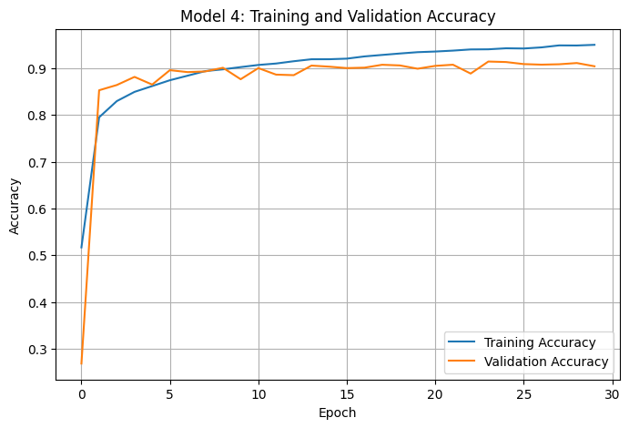

```python
plt.figure(figsize=(8,5))
plt.plot(history4.history['accuracy'], label='Training Accuracy')
plt.plot(history4.history['val_accuracy'], label='Validation Accuracy')
plt.title('Model 4: Training and Validation Accuracy')
plt.xlabel('Epoch')
plt.ylabel('Accuracy')
plt.legend()
plt.grid(True)
plt.show()
```

**Observations:**

Our last CNN model has a design with four convolutional layers, gradually increasing the number of filters from 16 to 64. Each convolution is followed by a LeakyReLU activation, which helps keep the neurons active even for negative inputs. It included max-pooling layers and batch normalisation twice, which helps reduce the spatial size and stabilise training. After flattening, a small dense layer with 32 nodes and a dropout of 0.5 was added to reduce overfitting before the final softmax layer that outputs predictions for the 10 classes.

During training over 30 epochs, the model **quickly improved in accuracy**, reaching over 95% on the training set and about 90% on the validation data. The **loss steadily decreased**, showing that the model was learning well. Although validation accuracy slightly fluctuated towards the end, overall the model generalised nicely without much overfitting. This indicates that the combination of dropout and batch normalisation was effective in keeping the model balanced between learning and avoiding memorising the training data.

## **Predictions on the test data**

- Make predictions on the test set using the second model.
- Print the obtained results using the classification report and the confusion matrix.
- Final observations on the obtained results.

### **Make predictions on the test data using the second model.**

```python
y_pred_probs = model4.predict(X_test)
y_pred_classes = y_pred_probs.argmax(axis=1)
y_test_classes = y_test_oh.argmax(axis=1)
```

```
563/563 ━━━━━━━━━━━━━━━━━━━━ 13s 23ms/step
```

**Note:** Earlier, we noticed that each entry of the target variable is a one-hot encoded vector, but to print the classification report and confusion matrix, we must convert each entry of y_test to a single label.

```python
y_test_labels = np.argmax(y_test_oh, axis=1)
y_pred_labels = np.argmax(y_pred_probs, axis=1)
```

```python
print(classification_report(y_test_labels, y_pred_labels))
print(confusion_matrix(y_test_labels, y_pred_labels))
```

```
              precision    recall  f1-score   support

           0       0.91      0.94      0.93      1814
           1       0.90      0.90      0.90      1828
           2       0.93      0.90      0.92      1803
           3       0.86      0.89      0.87      1719
           4       0.91      0.92      0.92      1812
           5       0.89      0.90      0.90      1768
           6       0.88      0.89      0.89      1832
           7       0.94      0.91      0.92      1808
           8       0.90      0.86      0.88      1812
           9       0.90      0.89      0.90      1804

    accuracy                           0.90     18000
   macro avg       0.90      0.90      0.90     18000
weighted avg       0.90      0.90      0.90     18000

[[1709   18    6    9   10    4   20    5    8   25]
 [  20 1654    8   28   48   12    7   24   22    5]
 [  12   19 1629   29   21    6    5   36   15   31]
 [   5   12   23 1523   14   64   25   11   33    9]
 [   8   33   19   18 1664   13   21    6    8   22]
 [   5   10    7   57    5 1598   48    3   11   24]
 [  31    9    7   25   18   54 1634    3   41   10]
 [  19   48   28   31   15    3    8 1642    5    9]
 [  31   14    4   34   19   16   81    5 1566   42]
 [  39   14   25   19   10   32   10   15   27 1613]]
```

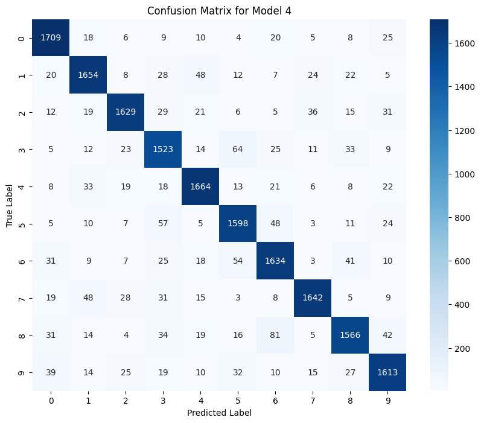

```python
class_names = [str(i) for i in range(10)]
cm = confusion_matrix(y_test_labels, y_pred_labels)

plt.figure(figsize=(10, 8))
sns.heatmap(cm, annot=True, fmt='d', cmap='Blues',
            xticklabels=class_names, yticklabels=class_names)
plt.xlabel('Predicted Label')
plt.ylabel('True Label')
plt.title('Confusion Matrix for Model 4')
plt.show()
```

### **Write your final observations on the performance of the model on the test data.**

**Final Observations:**

Our last model achieved test accuracy of approximately 90%, which is a good result for this type of **image classification** task. It shows that the model has learned to generalise well and can correctly classify most unseen images.

Across all classes, precision, recall, and F1-scores remained consistently high around 0.88 to 0.94 which means the model is both good at identifying the correct class and avoiding false positives. Classes 0, 2, and 7 stood out with especially high scores, suggesting the model is particularly confident in recognising those. On the other hand, classes like 3 and 6 showed slightly lower performance, indicating these might be more difficult to distinguish because they are visually similar.

The confusion matrix confirms this, as most misclassifications occur between neighbouring or similar looking digits, such as 3 being confused with 5 or 6, and 8 with 6. These types of errors are quite common and understandable in digit classification.

Although there are a few challenging classes, the macro and weighted averages for all metrics remain close to 0.90, suggesting that the model maintains consistently good performance across all classes without noticeably favouring any particular one.

Overall, the model did a solid and reliable job, especially considering its relatively simple architecture. That said, it may still benefit from further enhancements such as data augmentation, learning rate scheduling, or regularisation techniques, which could help refine its performance on the more challenging classes.

Recommendations for model performance improvement:

a) Data Augmentation:

We can introduce more variety in the training images by applying random transformations like rotations, shifts, flips, or zooms. This helps the model generalise better by seeing slightly different versions of the data.

b) Deeper or Wider Network:

We can experiment with adding more convolutional layers or increasing the number of filters. This can help the model learn more complex features, we have to be careful not to overfit.

c) Learning Rate Scheduling:

We can use learning rate schedulers that reduce the learning rate when the validation loss plateaus. This can help the model converge more smoothly and potentially find a better minimum.

d) Regularisation Techniques:

We can try adding weight decay (L2 regularisation) or increasing dropout rate to prevent overfitting further.

e) Advanced Optimizers:

Besides Adam, we can experiment with optimisers like AdamW, Ranger, or look into different hyperparameters for Adam.

f) Transfer Learning:

We can use a pretrained model (like one trained on ImageNet) and fine-tune it on our dataset. This is especially useful if our dataset is limited.

g) Ensemble Methods:

We can combine predictions from multiple models trained differently to improve robustness and accuracy.

h) Hyperparameter Tuning:

We can use grid search or automated tools like Keras Tuner to systematically find the best batch size, learning rate, number of layers, etc.